# Homework_3

Hilal Hakkoymaz

[figure not shown]

WELCOME

# Homework 3

## Q.2 Stroop, standing up or sitting down

### Fit an appropriate model to Stroop standing data

let`s read the data!

```r
library(tidyverse)
library(ggplot2)
library(readr)
library(dplyr)

stroop_standing_data <- read_csv("R_homework/Homework_3/stroop_standing_data.csv")

View(stroop_standing_data)

str(stroop_standing_data)
```

```
## spec_tbl_df [32,121 x 11] (S3: spec_tbl_df/tbl_df/tbl/data.frame)
##  $ subject   : num [1:32121] 1 1 1 1 1 1 1 1 1 1 ...
##  $ age       : num [1:32121] 20 20 20 20 20 20 20 20 20 20 ...
##  $ gender    : chr [1:32121] "m" "m" "m" "m" ...
##  $ condition : num [1:32121] 1 1 1 1 1 1 1 1 1 1 ...
##  $ phase     : chr [1:32121] "practice" "practice" "practice" "practice" ...
##  $ trial     : num [1:32121] 0 1 2 3 4 5 6 7 8 9 ...
##  $ stimulus  : chr [1:32121] "XXXXX" "RED" "XXXXX" "BLUE" ...
##  $ congruency: chr [1:32121] "baseline" "incongruent" "baseline" "incongruent" ...
##  $ rt        : chr [1:32121] "200" "1288" "1070" "1250" ...
##  $ correct   : num [1:32121] 0 0 1 0 1 1 1 1 999 0 ...
##  $ ...11     : logi [1:32121] NA NA NA NA NA NA ...
##  - attr(*, "spec")=
##   .. cols(
##   ..   subject = col_double(),
##   ..   age = col_double(),
##   ..   gender = col_character(),
##   ..   condition = col_double(),
##   ..   phase = col_character(),
##   ..   trial = col_double(),
##   ..   stimulus = col_character(),
##   ..   congruency = col_character(),
##   ..   rt = col_character(),
##   ..   correct = col_double(),
##   ..   ...11 = col_logical()
##   .. )
##  - attr(*, "problems")=<externalptr>
```

```r
df <- stroop_standing_data

summary(df)
```

```
##     subject           age           gender            condition
##  Min.   :  1.0   Min.   :17.00   Length:32121       Min.   :1.000
##  1st Qu.: 31.0   1st Qu.:18.00   Class :character   1st Qu.:1.000
##  Median : 62.0   Median :20.00   Mode  :character   Median :2.000
##  Mean   : 61.6   Mean   :20.14                      Mean   :1.508
##  3rd Qu.: 92.0   3rd Qu.:21.00                      3rd Qu.:2.000
##  Max.   :122.0   Max.   :35.00                      Max.   :2.000
##
##     phase               trial          stimulus          congruency
##  Length:32121       Min.   :  0.00   Length:32121       Length:32121
##  Class :character   1st Qu.: 22.00   Class :character   Class :character
##  Mode  :character   Median : 44.00   Mode  :character   Mode  :character
##                     Mean   : 48.11
##                     3rd Qu.: 75.00
##                     Max.   :107.00
##
##       rt               correct         ...11
##  Length:32121       Min.   :   0.00   Mode:logical
##  Class :character   1st Qu.:   1.00   TRUE:7
##  Mode  :character   Median :   1.00   NA's:32114
##                     Mean   :  77.96
##                     3rd Qu.:   1.00
##                     Max.   :1249.00
##                     NA's   :298
```

1. Cleaning raw data =

```r
df %>%
  count(phase, stimulus)
```

```
## # A tibble: 21 x 3
##    phase    stimulus     n
##    <chr>    <chr>    <int>
##  1 practice BLUE       958
##  2 practice BROWN      952
##  3 practice GREEN      986
##  4 practice RED        950
##  5 practice XXX        491
##  6 practice XXXX       485
##  7 practice XXXXX      947
##  8 sitting  BLUE      2220
##  9 sitting  BROWN     2176
## 10 sitting  GREEN     2205
## # ... with 11 more rows
```

```r
newdf1 <- df %>% mutate(correct = ifelse(correct > 3 , NA , correct ))

newdf1$stimulus[newdf1$stimulus == "XXX"] <- NA
newdf1$stimulus[newdf1$stimulus == "XXXX"] <- NA
newdf1$stimulus[newdf1$stimulus == "XXXXX"] <- NA

newdf1$congruency[newdf1$congruency == "baseline"] <- NA   #try with baseline too

newdf1$phase[newdf1$phase == "practice"] <- NA
newdf1$rt[newdf1$rt == "FALSE"] <- NA

newdf1$...11 <- NULL  #remove column

glimpse(newdf1)
```

```
## Rows: 32,121
## Columns: 10
## $ subject    <dbl> 1, 1, 1, 1, 1, 1, 1, 1, 1, 1, 1, 1, 1, 1, 1, 1, 1, 1, 1, 1,~
## $ age        <dbl> 20, 20, 20, 20, 20, 20, 20, 20, 20, 20, 20, 20, 20, 20, 20,~
## $ gender     <chr> "m", "m", "m", "m", "m", "m", "m", "m", "m", "m", "m", "m",~
## $ condition  <dbl> 1, 1, 1, 1, 1, 1, 1, 1, 1, 1, 1, 1, 1, 1, 1, 1, 1, 1, 1, 1,~
## $ phase      <chr> NA, NA, NA, NA, NA, NA, NA, NA, NA, NA, NA, NA, NA, NA, NA,~
## $ trial      <dbl> 0, 1, 2, 3, 4, 5, 6, 7, 8, 9, 10, 11, 12, 13, 14, 15, 16, 1~
## $ stimulus   <chr> NA, "RED", NA, "BLUE", "BLUE", NA, NA, NA, "BLUE", "RED", "~
## $ congruency <chr> NA, "incongruent", NA, "incongruent", "congruent", NA, NA, ~
## $ rt         <chr> "200", "1288", "1070", "1250", "705", "690", "633", "718", ~
## $ correct    <dbl> 0, 0, 1, 0, 1, 1, 1, 1, NA, 0, 1, 1, 1, 0, 1, 1, NA, NA, NA~
```

2. Clean all NA

```r
sdf <- na.omit(newdf1)  #clean data set
```

```r
sdf$rt <- as.numeric(as.character(sdf$rt)) #character to numeric
```

```r
str(sdf)
```

```
## tibble [16,423 x 10] (S3: tbl_df/tbl/data.frame)
##  $ subject   : num [1:16423] 1 1 1 1 1 1 1 1 1 1 ...
##  $ age       : num [1:16423] 20 20 20 20 20 20 20 20 20 20 ...
##  $ gender    : chr [1:16423] "m" "m" "m" "m" ...
##  $ condition : num [1:16423] 1 1 1 1 1 1 1 1 1 1 ...
##  $ phase     : chr [1:16423] "standing" "standing" "standing" "standing" ...
##  $ trial     : num [1:16423] 0 2 6 7 8 10 11 12 13 14 ...
##  $ stimulus  : chr [1:16423] "RED" "RED" "GREEN" "GREEN" ...
##  $ congruency: chr [1:16423] "congruent" "incongruent" "congruent" "incongruent" ...
##  $ rt        : num [1:16423] 468 202 581 854 650 ...
##  $ correct   : num [1:16423] 1 1 1 1 1 1 0 1 1 1 ...
##  - attr(*, "na.action")= 'omit' Named int [1:15698] 1 2 3 4 5 6 7 8 9 10 ...
##   ..- attr(*, "names")= chr [1:15698] "1" "2" "3" "4" ...
```

3. Filter the data so we are only looking at correct trials / factors

```r
sdf <- sdf %>%
  filter(correct == 1)

sdf$congruency <- factor(sdf$congruency)  #factor
sdf$phase <- factor(sdf$phase)
```

```r
sgrouping2 <- group_by(sdf, subject, condition , phase, congruency)
sdf_summary2 <- summarise(sgrouping2, mean_rt = mean(rt))

sgrouping3 <- group_by(sdf, condition , phase, congruency)
sdf_summary3 <- summarise(sgrouping3, mean_rt = mean(rt))
print.data.frame(sdf_summary3)
```

```
##   condition    phase  congruency  mean_rt
## 1         1  sitting   congruent 796.5678
## 2         1  sitting incongruent 904.6151
## 3         1 standing   congruent 807.1646
## 4         1 standing incongruent 939.2009
## 5         2  sitting   congruent 832.8034
## 6         2  sitting incongruent 950.6788
## 7         2 standing   congruent 814.8527
## 8         2 standing incongruent 945.3041
```

```r
sdf_summary3$condition <- factor(sdf_summary3$condition)
```

5. Plot the variables and interaction between factors

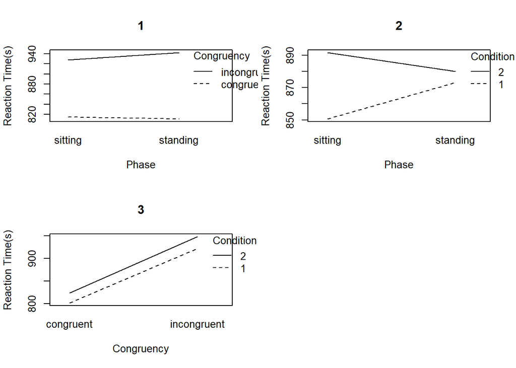

```r
par(mfrow = c(2,2))
interaction.plot(sdf_summary3$phase,sdf_summary3$congruency,sdf_summary3$mean_rt, main = "1", xlab = "Phase", ylab = "Reaction Time(s)", trace.label = "Congruency")
interaction.plot(sdf_summary3$phase,sdf_summary3$condition,sdf_summary3$mean_rt, main = "2", xlab = "Phase", ylab = "Reaction Time(s)", trace.label = "Condition")
interaction.plot(sdf_summary3$congruency,sdf_summary3$condition,sdf_summary3$mean_rt, main = "3",  xlab = "Congruency", ylab = "Reaction Time(s)", trace.label = "Condition")
par(mfrow = c(1,1))
```

- As seen in Chart 1, a faster response was given while sitting in the incongruent condition than standing, while the congruent condition was the opposite.
- Chart 2, trials started sitting or standing showed a faster response when the subjects continued in the same way as at the start, compared to the other conditions.
- In Graph 3, no matter how the trial started, congruent conditions had a faster response than incongruent conditions.

*Another graphic preference*

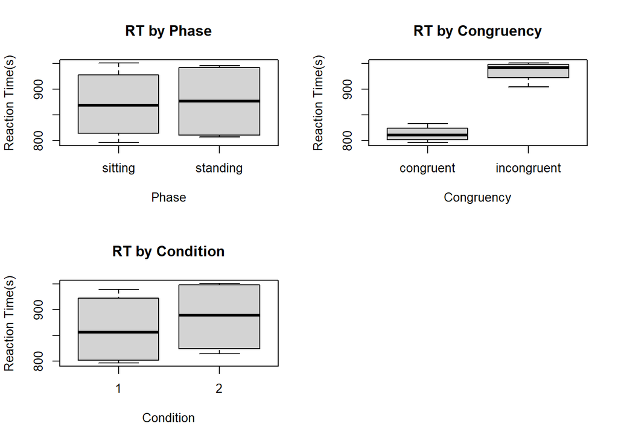

```r
par(mfrow = c(2,2))
boxplot(mean_rt~phase, data = sdf_summary3, main = "RT by Phase", xlab = "Phase", ylab = "Reaction Time(s)")
boxplot(mean_rt~congruency, data = sdf_summary3, main = "RT by Congruency", xlab = "Congruency", ylab = "Reaction Time(s)")
boxplot(mean_rt~condition, data = sdf_summary3, main = "RT by Condition", xlab = "Condition", ylab = "Reaction Time(s)")
par(mfrow = c(1,1))
```

*Let`s model the main effect*

```r
smodel1 = lm(mean_rt ~ ., data= sdf_summary3)
summary(smodel1)
```

```
##
## Call:
## lm(formula = mean_rt ~ ., data = sdf_summary3)
##
## Residuals:
##       1       2       3       4       5       6       7       8
##  -1.536 -15.591   3.597  13.530  10.677   6.450 -12.738  -4.389
##
## Coefficients:
##                       Estimate Std. Error t value Pr(>|t|)
## (Intercept)            798.104      9.865  80.901  1.4e-07 ***
## condition2              24.023      9.865   2.435 0.071585 .
## phasestanding            5.464      9.865   0.554 0.609151
## congruencyincongruent  122.103      9.865  12.377 0.000245 ***
## ---
## Signif. codes:  0 '***' 0.001 '**' 0.01 '*' 0.05 '.' 0.1 ' ' 1
##
## Residual standard error: 13.95 on 4 degrees of freedom
## Multiple R-squared:  0.9755, Adjusted R-squared:  0.9572
## F-statistic: 53.14 on 3 and 4 DF,  p-value: 0.001114
```

```r
#or

smodel1 = lm(mean_rt ~ condition + phase + congruency , data= sdf_summary3)
summary(smodel1)
```

```
##
## Call:
## lm(formula = mean_rt ~ condition + phase + congruency, data = sdf_summary3)
##
## Residuals:
##       1       2       3       4       5       6       7       8
##  -1.536 -15.591   3.597  13.530  10.677   6.450 -12.738  -4.389
##
## Coefficients:
##                       Estimate Std. Error t value Pr(>|t|)
## (Intercept)            798.104      9.865  80.901  1.4e-07 ***
## condition2              24.023      9.865   2.435 0.071585 .
## phasestanding            5.464      9.865   0.554 0.609151
## congruencyincongruent  122.103      9.865  12.377 0.000245 ***
## ---
## Signif. codes:  0 '***' 0.001 '**' 0.01 '*' 0.05 '.' 0.1 ' ' 1
##
## Residual standard error: 13.95 on 4 degrees of freedom
## Multiple R-squared:  0.9755, Adjusted R-squared:  0.9572
## F-statistic: 53.14 on 3 and 4 DF,  p-value: 0.001114
```

*Let`s add two-factor interactions* When we add interactions to model, there will be decrease in proportion of main effects.As we see from data model, there is a significant effect of Congruency on reaction time.

```r
smodel2 = lm(mean_rt ~ .^2 , data= sdf_summary3)
summary(smodel2)
```

```
##
## Call:
## lm(formula = mean_rt ~ .^2, data = sdf_summary3)
##
## Residuals:
##      1      2      3      4      5      6      7      8
##  1.427 -1.427 -1.427  1.427 -1.427  1.427  1.427 -1.427
##
## Coefficients:
##                                     Estimate Std. Error t value Pr(>|t|)
## (Intercept)                          795.141      3.775 210.660  0.00302 **
## condition2                            39.089      4.942   7.909  0.08006 .
## phasestanding                         13.450      4.942   2.722  0.22417
## congruencyincongruent                110.901      4.942  22.440  0.02835 *
## condition2:phasestanding             -34.254      5.707  -6.003  0.10509
## condition2:congruencyincongruent       4.122      5.707   0.722  0.60179
## phasestanding:congruencyincongruent   18.282      5.707   3.204  0.19261
## ---
## Signif. codes:  0 '***' 0.001 '**' 0.01 '*' 0.05 '.' 0.1 ' ' 1
##
## Residual standard error: 4.035 on 1 degrees of freedom
## Multiple R-squared:  0.9995, Adjusted R-squared:  0.9964
## F-statistic: 325.4 on 6 and 1 DF,  p-value: 0.04241
```

*Full model (3 factor) interaction = r2 equals 1 because all data varience equals 1*

```r
smodel3 = lm(mean_rt ~ .^3 , data= sdf_summary3)
summary(smodel3)
```

```
##
## Call:
## lm(formula = mean_rt ~ .^3, data = sdf_summary3)
##
## Residuals:
## ALL 8 residuals are 0: no residual degrees of freedom!
##
## Coefficients:
##                                                Estimate Std. Error t value
## (Intercept)                                     796.568        NaN     NaN
## condition2                                       36.236        NaN     NaN
## phasestanding                                    10.597        NaN     NaN
## congruencyincongruent                           108.047        NaN     NaN
## condition2:phasestanding                        -28.547        NaN     NaN
## condition2:congruencyincongruent                  9.828        NaN     NaN
## phasestanding:congruencyincongruent              23.989        NaN     NaN
## condition2:phasestanding:congruencyincongruent  -11.413        NaN     NaN
##                                                Pr(>|t|)
## (Intercept)                                         NaN
## condition2                                          NaN
## phasestanding                                       NaN
## congruencyincongruent                               NaN
## condition2:phasestanding                            NaN
## condition2:congruencyincongruent                    NaN
## phasestanding:congruencyincongruent                 NaN
## condition2:phasestanding:congruencyincongruent      NaN
##
## Residual standard error: NaN on 0 degrees of freedom
## Multiple R-squared:      1,  Adjusted R-squared:    NaN
## F-statistic:   NaN on 7 and 0 DF,  p-value: NA
```

*We can also calculate specific interactions*

```r
smodel4 = lm(mean_rt ~ congruency + phase*condition , data= sdf_summary3)
summary(smodel4)
```

```
##
## Call:
## lm(formula = mean_rt ~ congruency + phase * condition, data = sdf_summary3)
##
## Residuals:
##      1      2      3      4      5      6      7      8
##  7.028 -7.028 -4.967  4.967  2.114 -2.114 -4.174  4.174
##
## Coefficients:
##                          Estimate Std. Error t value Pr(>|t|)
## (Intercept)               789.540      6.323 124.870 1.13e-06 ***
## congruencyincongruent     122.103      5.655  21.591 0.000217 ***
## phasestanding              22.591      7.998   2.825 0.066483 .
## condition2                 41.150      7.998   5.145 0.014229 *
## phasestanding:condition2  -34.254     11.311  -3.028 0.056381 .
## ---
## Signif. codes:  0 '***' 0.001 '**' 0.01 '*' 0.05 '.' 0.1 ' ' 1
##
## Residual standard error: 7.998 on 3 degrees of freedom
## Multiple R-squared:  0.994,  Adjusted R-squared:  0.9859
## F-statistic: 123.6 on 4 and 3 DF,  p-value: 0.001167
```

```r
aov1.out = aov(mean_rt ~ ., data= sdf_summary3) #main factors
summary(aov1.out)
```

```
##             Df Sum Sq Mean Sq F value   Pr(>F)
## condition    1   1154    1154   5.930 0.071585 .
## phase        1     60      60   0.307 0.609151
## congruency   1  29818   29818 153.195 0.000245 ***
## Residuals    4    779     195
## ---
## Signif. codes:  0 '***' 0.001 '**' 0.01 '*' 0.05 '.' 0.1 ' ' 1
```

```r
aov2.out = aov(mean_rt ~ .^2 , data= sdf_summary3) #2 factor interaction
summary(aov2.out)
```

```
##                      Df Sum Sq Mean Sq  F value Pr(>F)
## condition             1   1154    1154   70.885 0.0753 .
## phase                 1     60      60    3.668 0.3064
## congruency            1  29818   29818 1831.318 0.0149 *
## condition:phase       1    587     587   36.031 0.1051
## condition:congruency  1      8       8    0.522 0.6018
## phase:congruency      1    167     167   10.264 0.1926
## Residuals             1     16      16
## ---
## Signif. codes:  0 '***' 0.001 '**' 0.01 '*' 0.05 '.' 0.1 ' ' 1
```

```r
aov3.out = aov(mean_rt ~ .^3 , data= sdf_summary3) #whole pie
summary(aov3.out)
```

```
##                            Df Sum Sq Mean Sq
## condition                   1   1154    1154
## phase                       1     60      60
## congruency                  1  29818   29818
## condition:phase             1    587     587
## condition:congruency        1      8       8
## phase:congruency            1    167     167
## condition:phase:congruency  1     16      16
```

```r
aov4.out = aov(mean_rt ~ congruency + phase*condition , data= sdf_summary3) #specific interaction
summary(aov4.out)
```

```
##                 Df Sum Sq Mean Sq F value   Pr(>F)
## congruency       1  29818   29818 466.150 0.000217 ***
## phase            1     60      60   0.934 0.405209
## condition        1   1154    1154  18.043 0.023905 *
## phase:condition  1    587     587   9.171 0.056381 .
## Residuals        3    192      64
## ---
## Signif. codes:  0 '***' 0.001 '**' 0.01 '*' 0.05 '.' 0.1 ' ' 1
```

- some interaction plots

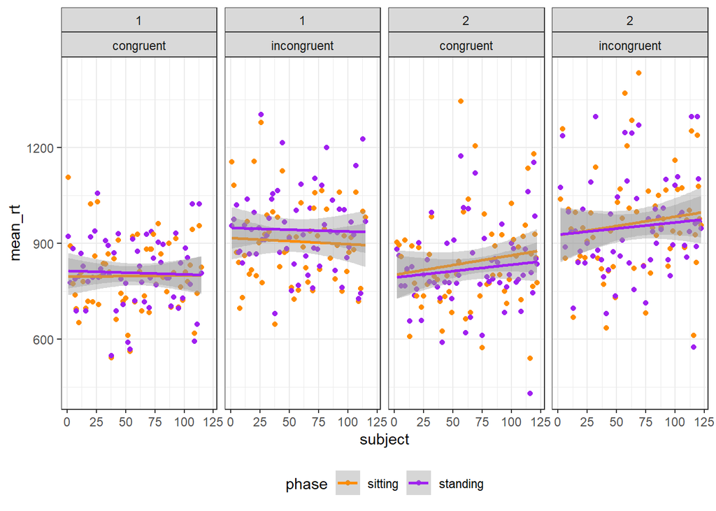

```r
sdf_summary2 %>%
  ggplot(mapping = aes(x = subject, y = mean_rt, color = phase)) + facet_grid(~ condition*congruency) + geom_point() + theme_bw() + theme(legend.position = "bottom") +
  stat_smooth(method = "lm") + scale_color_manual(values=c("darkorange", "purple"))
```

- distribution of the participants according to the experimental factors

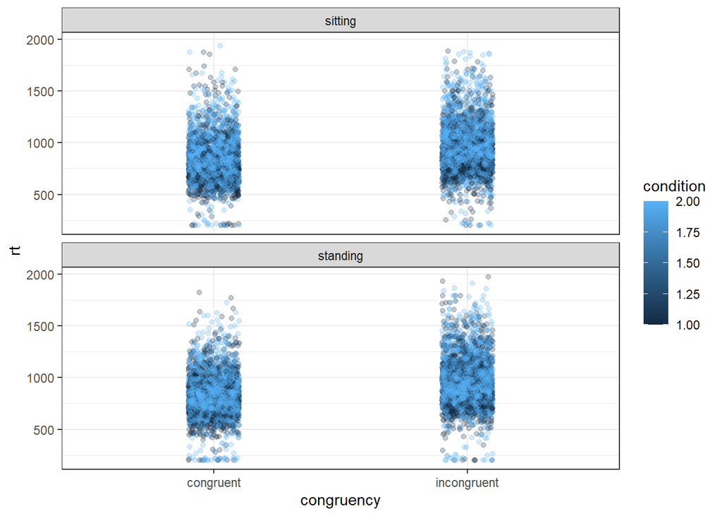

```r
ggplot(sdf, aes(x = congruency, y = rt)) +
  geom_jitter(width = 0.1, height = 0, alpha = 0.25, aes(color = condition)) +
  facet_wrap(~ phase, nrow = 2) +
  theme_bw()
```

## Q.3 The Dimensions of Popular Music

### Applying PCA to the Top 200 songs from Spotify

1. Let start with reading data.

```r
library(tidyverse)
library(ggplot2)
library(readr)
library(dplyr)
library(httr)
library(ggthemes)
library(factoextra)

spotify_clean <- read_csv("spotify_clean.csv")
View(spotify_clean)

spotify <- spotify_clean
glimpse(spotify)
```

```
## Rows: 200
## Columns: 17
## $ ...1             <dbl> 0, 1, 2, 3, 4, 5, 6, 7, 8, 9, 10, 11, 12, 13, 14, 15,~
## $ `Track Name`     <chr> "Havana", "rockstar", "River (feat. Ed Sheeran)", "Ne~
## $ Artist           <chr> "Camila Cabello", "Post Malone", "Eminem", "Camila Ca~
## $ Streams          <dbl> 30948101, 27643632, 22610091, 22147865, 20387864, 199~
## $ danceability     <dbl> 0.765, 0.577, 0.757, 0.637, 0.704, 0.715, 0.771, 0.72~
## $ energy           <dbl> 0.523, 0.522, 0.748, 0.713, 0.859, 0.802, 0.696, 0.89~
## $ key              <dbl> 2, 5, 8, 0, 5, 11, 9, 7, 2, 5, 8, 5, 5, 8, 1, 8, 8, 4~
## $ loudness         <dbl> -4.333, -6.594, -5.794, -4.333, -4.877, -4.647, -6.25~
## $ mode             <dbl> 1, 0, 0, 1, 0, 0, 0, 1, 1, 0, 1, 0, 0, 0, 0, 1, 1, 1,~
## $ speechiness      <dbl> 0.0300, 0.0984, 0.4730, 0.0747, 0.0996, 0.0394, 0.075~
## $ acousticness     <dbl> 0.184000, 0.130000, 0.170000, 0.181000, 0.018500, 0.1~
## $ instrumentalness <dbl> 3.56e-05, 9.03e-05, 0.00e+00, 6.37e-04, 0.00e+00, 0.0~
## $ liveness         <dbl> 0.1320, 0.1420, 0.0759, 0.1370, 0.0215, 0.1770, 0.179~
## $ valence          <dbl> 0.3940, 0.1190, 0.6930, 0.2430, 0.9260, 0.3270, 0.656~
## $ tempo            <dbl> 104.988, 159.772, 90.052, 129.923, 105.115, 124.989, ~
## $ time_signature   <dbl> 4, 4, 4, 4, 4, 4, 4, 4, 4, 4, 3, 4, 4, 4, 4, 4, 3, 4,~
## $ duration_sec     <dbl> 217, 218, 221, 226, 217, 197, 208, 173, 268, 212, 263~
```

2. Some trends:

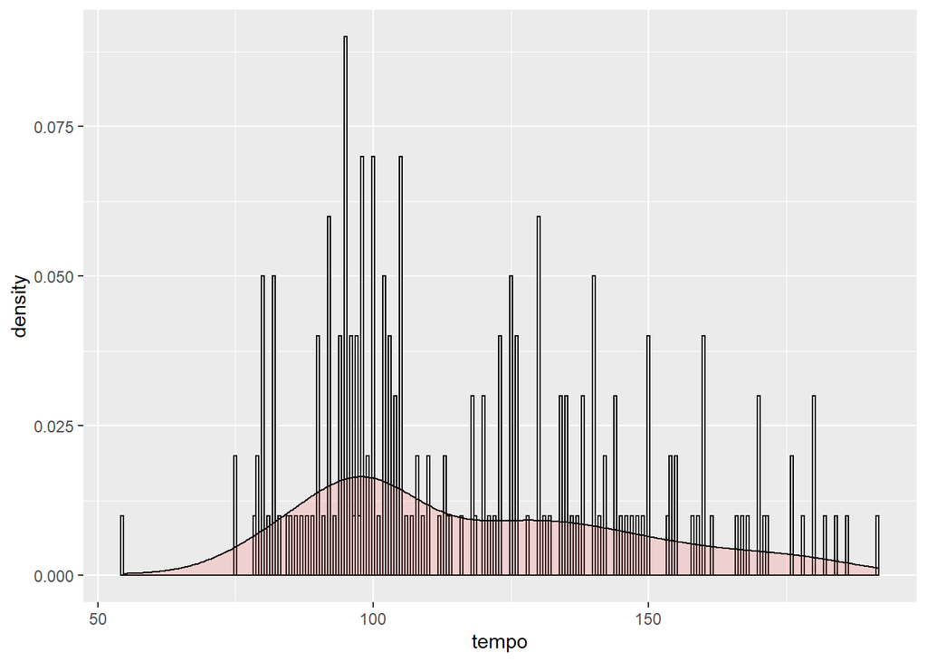

```r
ggplot(spotify, aes(x=tempo)) +
geom_histogram(aes(y=..density..),      # Histogram with density instead of count on y-axis
                 binwidth=.5,
                 colour="black", fill="white") +
geom_density(alpha=.2, fill="#FF6666")
```

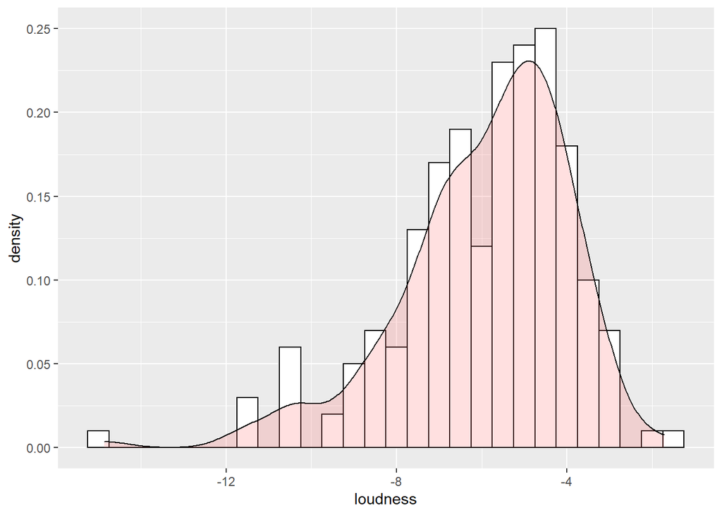

```r
ggplot(spotify, aes(x=loudness)) +
  geom_histogram(aes(y=..density..),      # Histogram with density instead of count on y-axis
                 binwidth=.5,
                 colour="black", fill="white") +
  geom_density(alpha=.2, fill="#FF6666")
```

3. Lets look data correlation.

[figure not shown]

Correlation matrix

```r
library(corrplot)

dms <- select(spotify, danceability, energy, loudness, valence, acousticness, tempo, duration_sec, instrumentalness, key, liveness, mode, speechiness )

dms.cor = cor(dms)
dfs.cor <- data.frame(dms.cor)

#how to create matrix bar --> corrplot(dms.cor,method = 'square', order = 'AOE', addCoef.col = 'black', tl.col="black", tl.srt=45, cl.pos = 'n', col = COL2('RdBu'))
```

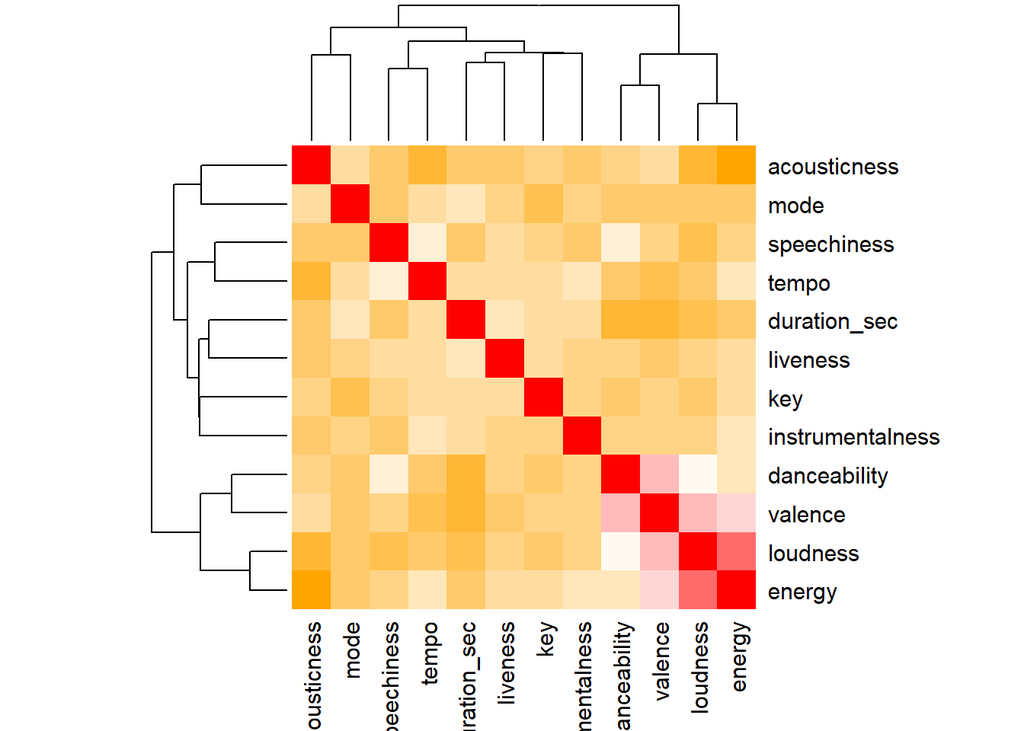

```r
palette = colorRampPalette(c("orange", "white", "red")) (20)
heatmap(x = dms.cor, col = palette, symm = TRUE)
```

*Another way of display matrix.*

4. Principal Component Analysis as Original

```r
pca_dms1 <- prcomp(dms)
summary(pca_dms1)
```

```
## Importance of components:
##                            PC1     PC2     PC3    PC4     PC5     PC6     PC7
## Standard deviation     38.6494 28.8325 3.74060 1.9357 0.46579 0.20839 0.18091
## Proportion of Variance  0.6375  0.3548 0.00597 0.0016 0.00009 0.00002 0.00001
## Cumulative Proportion   0.6375  0.9923 0.99826 0.9999 0.99995 0.99997 0.99998
##                            PC8   PC9    PC10    PC11    PC12
## Standard deviation     0.11927 0.104 0.09086 0.07812 0.01857
## Proportion of Variance 0.00001 0.000 0.00000 0.00000 0.00000
## Cumulative Proportion  0.99999 1.000 1.00000 1.00000 1.00000
```

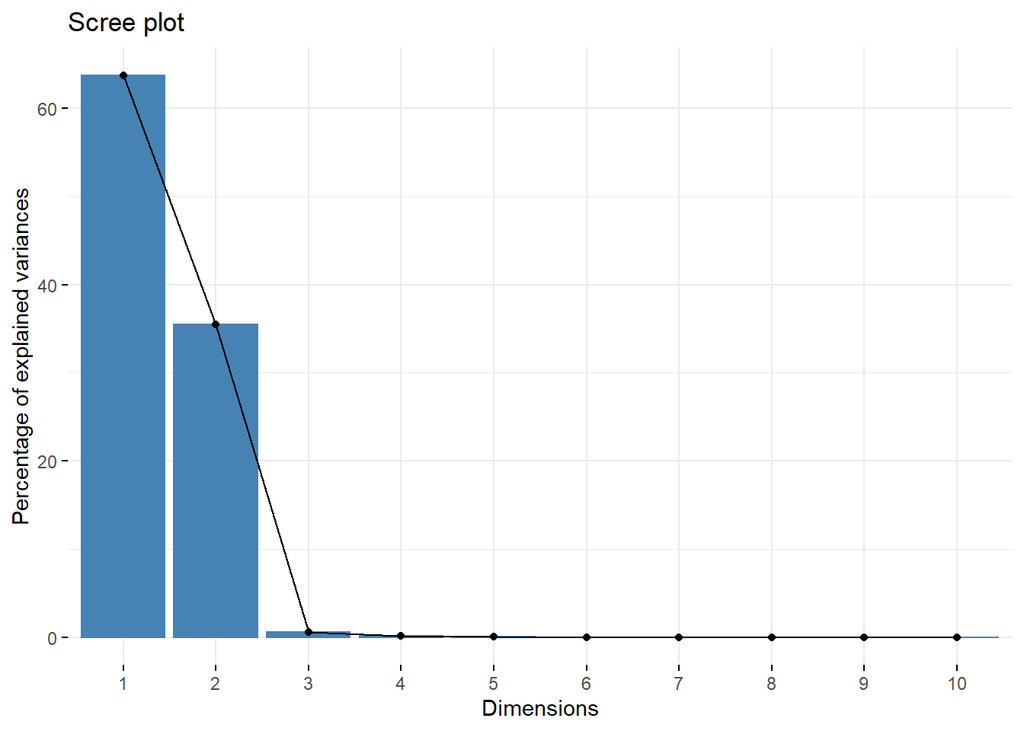

```r
factoextra::fviz_eig(pca_dms1) #plot
```

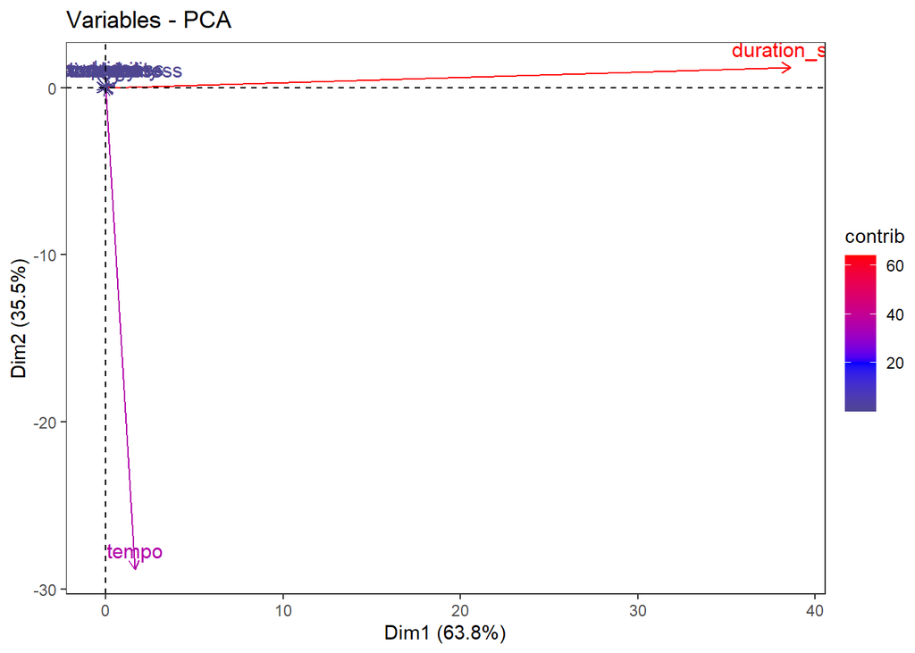

```r
fviz_pca_var(pca_dms1, col.var="contrib")+
  scale_color_gradient2(low="darkgreen", mid="blue",
                        high="red", midpoint=20) +
  theme_test() # Control variable colors using their contributions
```

- 64% variance was explained by Principal component 1 and 35% was explained by Principal component 2.
- The element that explains the most variance in Dimension 1 is Duration time(sec).

```
attach(scores)
plot(x = scores$PC1 , y = scores$PC2, pch = 19, col = "orange", main="Styled Scatter",
     xlab="PC1 ", ylab="PC2") +
abline(lm(PC2~PC1), col="black")
```

[figure not shown]

5. Better approach for him = Let1s remove Duration time.

```r
dms %>% select(-duration_sec) -> d_nodur
pca_nodur <- prcomp(as.matrix(d_nodur), scale = FALSE)
summary(pca_nodur)
```

```
## Importance of components:
##                            PC1     PC2    PC3     PC4     PC5     PC6     PC7
## Standard deviation     28.8531 3.74124 1.9571 0.46794 0.21332 0.18093 0.12013
## Proportion of Variance  0.9787 0.01645 0.0045 0.00026 0.00005 0.00004 0.00002
## Cumulative Proportion   0.9787 0.99510 0.9996 0.99986 0.99991 0.99995 0.99997
##                            PC8     PC9    PC10    PC11
## Standard deviation     0.10435 0.09166 0.07813 0.01858
## Proportion of Variance 0.00001 0.00001 0.00001 0.00000
## Cumulative Proportion  0.99998 0.99999 1.00000 1.00000
```

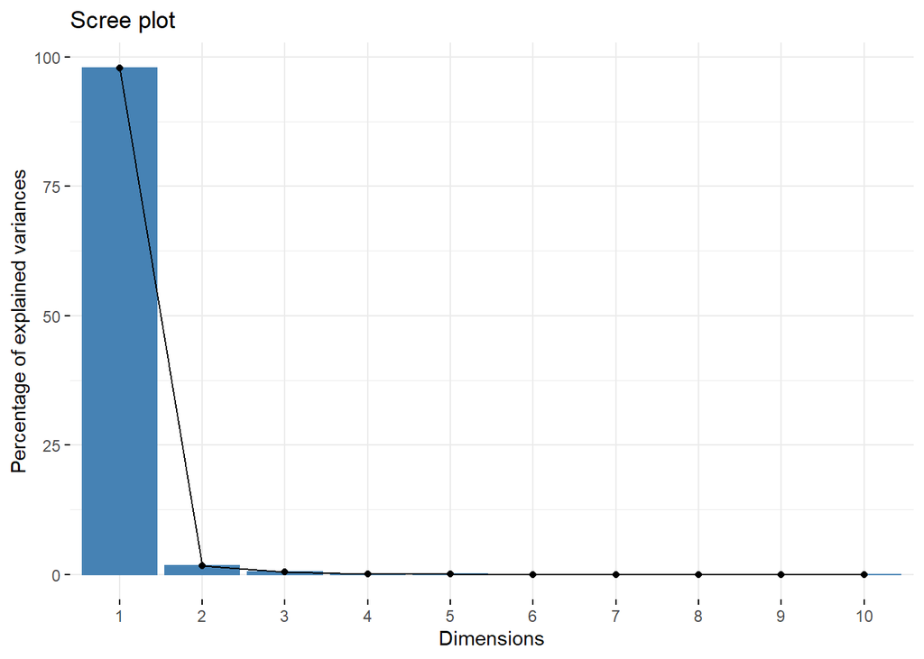

```r
factoextra::fviz_eig(pca_nodur) #plot
```

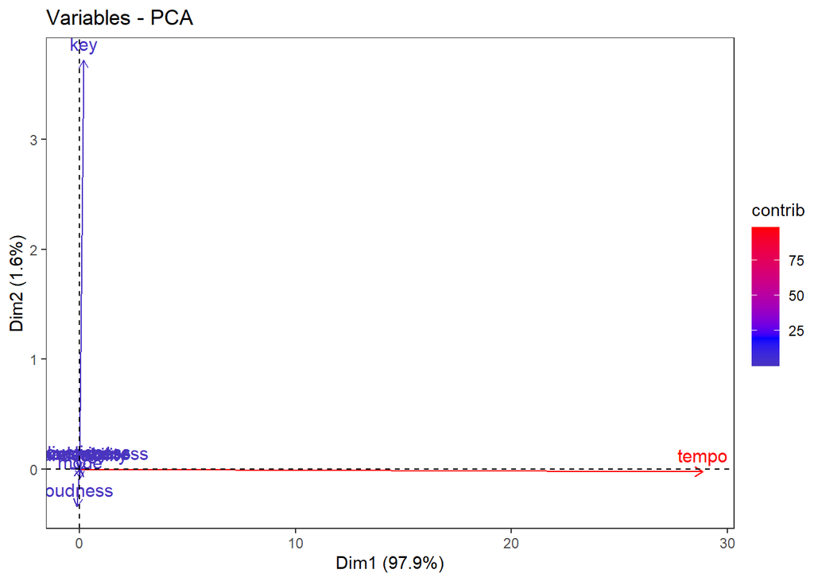

```r
fviz_pca_var(pca_nodur, col.var="contrib")+
  scale_color_gradient2(low="darkgreen", mid="blue",
                        high="red", midpoint=20) +
  theme_test()
```

*Now, %98 of varience explained by Principal component!*

```r
#the downside
cor.test(pca_nodur$x[,1], dms$duration_sec)
```

```
##
##  Pearson's product-moment correlation
##
## data:  pca_nodur$x[, 1] and dms$duration_sec
## t = 0.35415, df = 198, p-value = 0.7236
## alternative hypothesis: true correlation is not equal to 0
## 95 percent confidence interval:
##  -0.1139784  0.1633314
## sample estimates:
##       cor
## 0.0251605
```

*In our model, the statistics feature is not correlated with the other two*

### Now it is my turn ^ ^ This model comes to me meaningless.

1. Re-run, this time with scaling! (BECAUSE OUR VARIABLES NOT EQUAL IN SCALE)

```r
pca_dms2 <- prcomp(dms, center = TRUE, scale. = TRUE)
summary(pca_dms2)
```

```
## Importance of components:
##                           PC1    PC2    PC3     PC4     PC5     PC6     PC7
## Standard deviation     1.5430 1.2644 1.1556 1.08635 1.03529 0.95780 0.91431
## Proportion of Variance 0.1984 0.1332 0.1113 0.09835 0.08932 0.07645 0.06966
## Cumulative Proportion  0.1984 0.3316 0.4429 0.54126 0.63058 0.70703 0.77669
##                            PC8     PC9    PC10   PC11    PC12
## Standard deviation     0.88167 0.81310 0.79084 0.6187 0.48270
## Proportion of Variance 0.06478 0.05509 0.05212 0.0319 0.01942
## Cumulative Proportion  0.84147 0.89657 0.94869 0.9806 1.00000
```

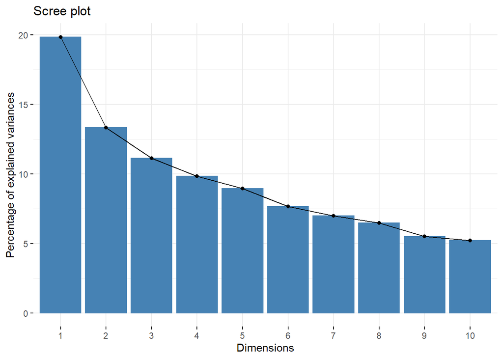

```r
factoextra::fviz_eig(pca_dms2) #plot
```

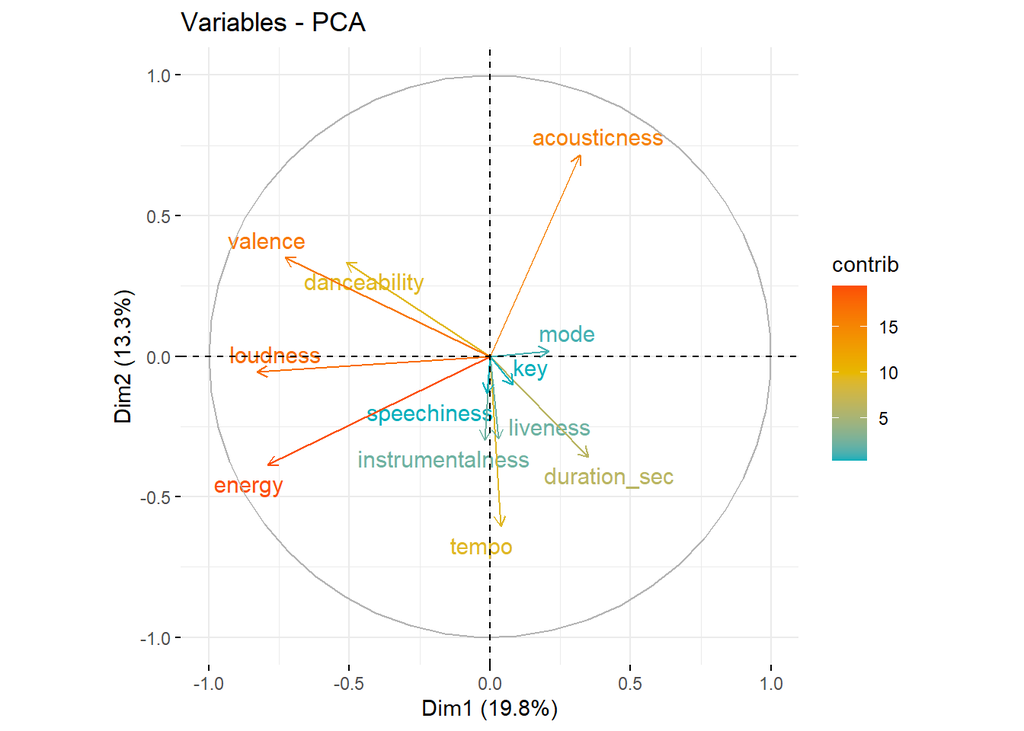

```r
fviz_pca_var(pca_dms2,
             axes = c(1, 2),
             col.var="contrib",
             gradient.cols = c("#00AFBB", "#E7B800", "#FC4E07"),
             repel = TRUE)
```

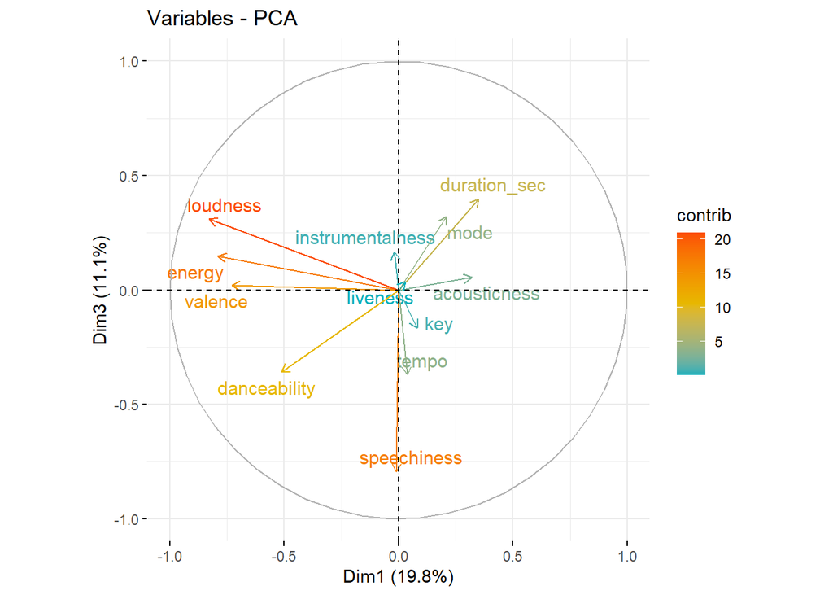

```r
#Different dimension
fviz_pca_var(pca_dms2,
             axes = c(1, 3),
             col.var="contrib",
             gradient.cols = c("#00AFBB", "#E7B800", "#FC4E07"),
             repel = TRUE)
```

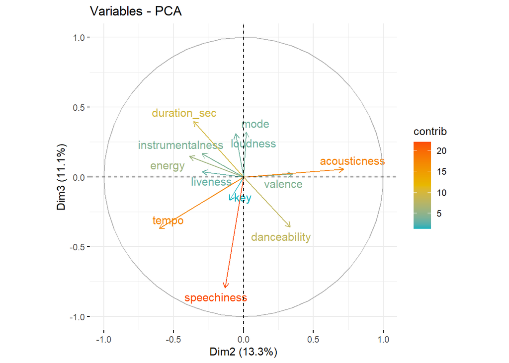

```r
#Different dimension
fviz_pca_var(pca_dms2,
             axes = c(2, 3),
             col.var="contrib",
             gradient.cols = c("#00AFBB", "#E7B800", "#FC4E07"),
             repel = TRUE)
```

*Now all variables has contributed varience in some extend*

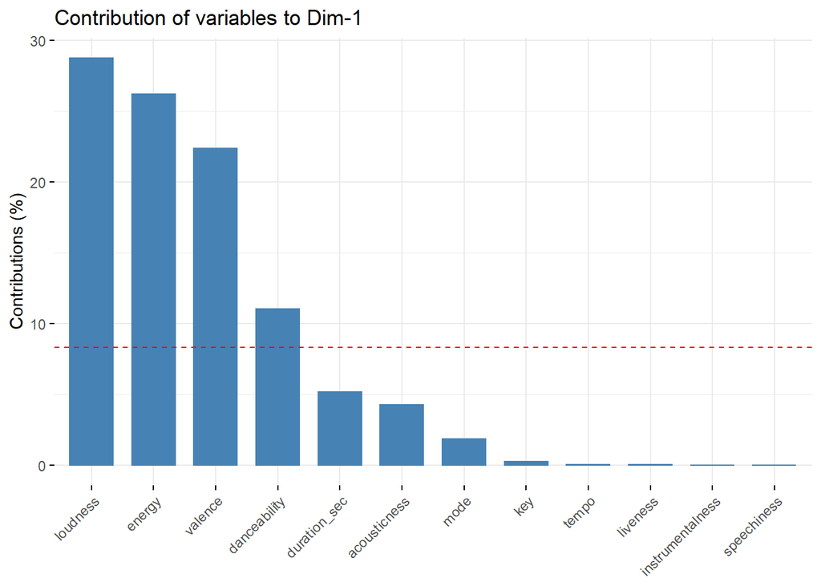

```r
# Contributions of variables to PC1/PC2/PC2
fviz_contrib(pca_dms2, choice = "var", axes = 1)
```

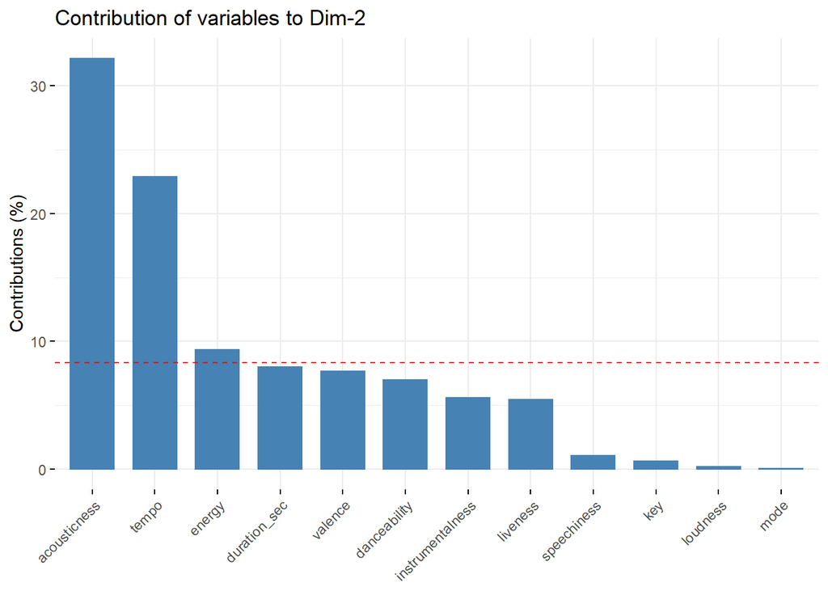

```r
fviz_contrib(pca_dms2, choice = "var", axes = 2)
```